# P8105 Intro to Linear Regression

Linh Tran

3/1/2021

# Introduction to Linear Models

## Model fitting

Load and clean Airbnb dataset

```r
data("nyc_airbnb")

nyc_airbnb =
  nyc_airbnb %>%
  mutate(stars = review_scores_location / 2) %>%
  rename(
    borough = neighbourhood_group,
    neighborhood = neighbourhood) %>%
  filter(borough != "Staten Island") %>%
  select(price, stars, borough, neighborhood, room_type)
```

Fit a model with price as an outcome that may depend on rating and borough

```r
fit = lm(price ~ stars + borough, data = nyc_airbnb)
```

**Be careful with factors**: Factor level is treated as the reference. Changing refefence categories won’t change fit, or statistical significance, but can affect ease of interpretation.

```r
nyc_airbnb =
  nyc_airbnb %>%
  mutate(
    borough = fct_infreq(borough),
    room_type = fct_infreq(room_type))

fit = lm(price ~ stars + borough, data = nyc_airbnb)
```

## Tidying output

Some common functions for interacting with `lm` fits

```r
summary(fit)
```

```
##
## Call:
## lm(formula = price ~ stars + borough, data = nyc_airbnb)
##
## Residuals:
##    Min     1Q Median     3Q    Max
## -169.8  -64.0  -29.0   20.2 9870.0
##
## Coefficients:
##                 Estimate Std. Error t value Pr(>|t|)
## (Intercept)       19.839     12.189   1.628    0.104
## stars             31.990      2.527  12.657   <2e-16 ***
## boroughBrooklyn  -49.754      2.235 -22.262   <2e-16 ***
## boroughQueens    -77.048      3.727 -20.675   <2e-16 ***
## boroughBronx     -90.254      8.567 -10.534   <2e-16 ***
## ---
## Signif. codes:  0 '***' 0.001 '**' 0.01 '*' 0.05 '.' 0.1 ' ' 1
##
## Residual standard error: 181.5 on 30525 degrees of freedom
##   (9962 observations deleted due to missingness)
## Multiple R-squared:  0.03423,    Adjusted R-squared:  0.03411
## F-statistic: 270.5 on 4 and 30525 DF,  p-value: < 2.2e-16
```

```r
summary(fit)$coef
```

```
##                  Estimate Std. Error    t value      Pr(>|t|)
## (Intercept)      19.83946  12.189256   1.627619  1.036160e-01
## stars            31.98989   2.527500  12.656733  1.269392e-36
## boroughBrooklyn -49.75363   2.234878 -22.262345 6.317605e-109
## boroughQueens   -77.04776   3.726632 -20.674904  2.584908e-94
## boroughBronx    -90.25393   8.567490 -10.534465  6.638618e-26
```

```r
coef(fit)
```

```
##     (Intercept)           stars boroughBrooklyn   boroughQueens    boroughBronx
##        19.83946        31.98989       -49.75363       -77.04776       -90.25393
```

```r
#fitted.values(fit)
```

### `broom` package for obtaining quick summary of the model and clean up the coefficient table (produce dataframes)

```r
fit %>%
  broom::glance()
```

```
## # A tibble: 1 x 12
##   r.squared adj.r.squared sigma statistic   p.value    df  logLik    AIC    BIC
##       <dbl>         <dbl> <dbl>     <dbl>     <dbl> <dbl>   <dbl>  <dbl>  <dbl>
## 1    0.0342        0.0341  182.      271. 6.73e-229     4 -2.02e5 4.04e5 4.04e5
## # … with 3 more variables: deviance <dbl>, df.residual <int>, nobs <int>
```

```r
fit %>%
  broom::tidy()
```

```
## # A tibble: 5 x 5
##   term            estimate std.error statistic   p.value
##   <chr>              <dbl>     <dbl>     <dbl>     <dbl>
## 1 (Intercept)         19.8     12.2       1.63 1.04e-  1
## 2 stars               32.0      2.53     12.7  1.27e- 36
## 3 boroughBrooklyn    -49.8      2.23    -22.3  6.32e-109
## 4 boroughQueens      -77.0      3.73    -20.7  2.58e- 94
## 5 boroughBronx       -90.3      8.57    -10.5  6.64e- 26
```

```r
fit %>%
  broom::tidy() %>%
  select(term, estimate, p.value) %>%
  mutate(term = str_replace(term, "^borough", "Borough")) %>%
  knitr::kable(digits = 3)
```

| term | estimate | p.value |
| --- | --- | --- |
| (Intercept) | 19.839 | 0.104 |
| stars | 31.990 | 0.000 |
| BoroughBrooklyn | -49.754 | 0.000 |
| BoroughQueens | -77.048 | 0.000 |
| BoroughBronx | -90.254 | 0.000 |

## Diagnostics

`modelr` package can be used to add residuals and fitted values to a dataframe

```r
modelr::add_residuals(nyc_airbnb, fit)
```

```
## # A tibble: 40,492 x 6
##    price stars borough neighborhood room_type        resid
##    <dbl> <dbl> <fct>   <chr>        <fct>            <dbl>
##  1    99   5   Bronx   City Island  Private room      9.47
##  2   200  NA   Bronx   City Island  Private room     NA
##  3   300  NA   Bronx   City Island  Entire home/apt  NA
##  4   125   5   Bronx   City Island  Entire home/apt  35.5
##  5    69   5   Bronx   City Island  Private room    -20.5
##  6   125   5   Bronx   City Island  Entire home/apt  35.5
##  7    85   5   Bronx   City Island  Entire home/apt  -4.53
##  8    39   4.5 Bronx   Allerton     Private room    -34.5
##  9    95   5   Bronx   Allerton     Entire home/apt   5.47
## 10   125   4.5 Bronx   Allerton     Entire home/apt  51.5
## # … with 40,482 more rows
```

```r
modelr::add_predictions(nyc_airbnb, fit)
```

```
## # A tibble: 40,492 x 6
##    price stars borough neighborhood room_type        pred
##    <dbl> <dbl> <fct>   <chr>        <fct>           <dbl>
##  1    99   5   Bronx   City Island  Private room     89.5
##  2   200  NA   Bronx   City Island  Private room     NA
##  3   300  NA   Bronx   City Island  Entire home/apt  NA
##  4   125   5   Bronx   City Island  Entire home/apt  89.5
##  5    69   5   Bronx   City Island  Private room     89.5
##  6   125   5   Bronx   City Island  Entire home/apt  89.5
##  7    85   5   Bronx   City Island  Entire home/apt  89.5
##  8    39   4.5 Bronx   Allerton     Private room     73.5
##  9    95   5   Bronx   Allerton     Entire home/apt  89.5
## 10   125   4.5 Bronx   Allerton     Entire home/apt  73.5
## # … with 40,482 more rows
```

Like many things in the tidyverse, the first argument is a dataframe. That makes it easy to included steps adding residuals or predictions in pipeline of commands to conduct inspections and perform diagnostics.

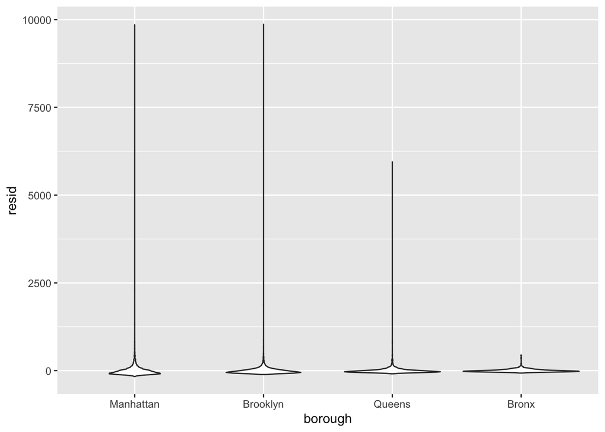

```r
nyc_airbnb %>%
  modelr::add_residuals(fit) %>%
  ggplot(aes(x = borough, y = resid)) + geom_violin()
```

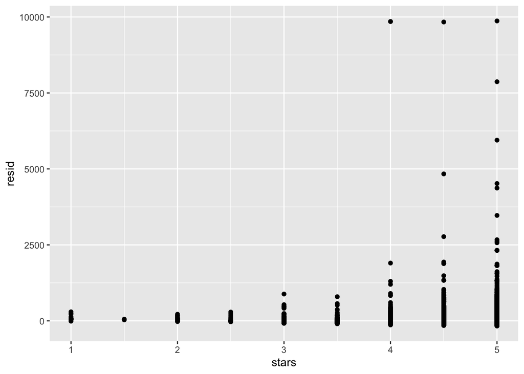

```r
nyc_airbnb %>%
  modelr::add_residuals(fit) %>%
  ggplot(aes(x = stars, y = resid)) + geom_point()
```

```r
# large outliers in price, skewed residual distribution. Can transform the price variable (e.g. log transformation, or fitting a model that is robust to outliers)
```

## Hypothesis Testing

Testing nested models using `anova` function, summarized using `broom::tidy`

```r
fit_null = lm(price ~ stars + borough, data = nyc_airbnb)
fit_alt = lm(price ~ stars + borough + room_type, data = nyc_airbnb)

anova(fit_null, fit_alt) %>%
  broom::tidy()
```

```
## # A tibble: 2 x 6
##   res.df         rss    df     sumsq statistic p.value
##    <dbl>       <dbl> <dbl>     <dbl>     <dbl>   <dbl>
## 1  30525 1005601724.    NA       NA        NA       NA
## 2  30523  921447496.     2 84154228.     1394.       0
```

**Only use for nested models**

## Nesting data fitting models to datasets nested within variables. (Different from fitting nested models)

Use `nest` to create a list column containing datasets and fit separate models to each.

E.g., we might think that star ratings and room type affects price differently in each borough. One way to allow this kind of effect modification is through interaction term

```r
nyc_airbnb %>%
  lm(price ~ stars * borough + room_type * borough, data = .) %>%
  broom::tidy() %>%
  knitr::kable(digits = 3)
```

| term | estimate | std.error | statistic | p.value |
| --- | --- | --- | --- | --- |
| (Intercept) | 95.694 | 19.184 | 4.988 | 0.000 |
| stars | 27.110 | 3.965 | 6.838 | 0.000 |
| boroughBrooklyn | -26.066 | 25.080 | -1.039 | 0.299 |
| boroughQueens | -4.118 | 40.674 | -0.101 | 0.919 |
| boroughBronx | -5.627 | 77.808 | -0.072 | 0.942 |
| room_typePrivate room | -124.188 | 2.996 | -41.457 | 0.000 |
| room_typeShared room | -153.635 | 8.692 | -17.676 | 0.000 |
| stars:boroughBrooklyn | -6.139 | 5.237 | -1.172 | 0.241 |
| stars:boroughQueens | -17.455 | 8.539 | -2.044 | 0.041 |
| stars:boroughBronx | -22.664 | 17.099 | -1.325 | 0.185 |
| boroughBrooklyn:room_typePrivate room | 31.965 | 4.328 | 7.386 | 0.000 |
| boroughQueens:room_typePrivate room | 54.933 | 7.459 | 7.365 | 0.000 |
| boroughBronx:room_typePrivate room | 71.273 | 18.002 | 3.959 | 0.000 |
| boroughBrooklyn:room_typeShared room | 47.797 | 13.895 | 3.440 | 0.001 |
| boroughQueens:room_typeShared room | 58.662 | 17.897 | 3.278 | 0.001 |
| boroughBronx:room_typeShared room | 83.089 | 42.451 | 1.957 | 0.050 |

Alternatively, we can nest within boroughs and fit borough-specific models associating price with rating and room type:

```r
nest_lm_res =
  nyc_airbnb %>%
  nest(data = -borough) %>%
  mutate(
    models = map(data, ~lm(price ~ stars + room_type, data = .x)),
    results = map(models, broom::tidy)) %>%
  select(-data, -models) %>%
  unnest(results)


nest_lm_res %>%
  select(borough, term, estimate) %>%
  mutate(term = fct_inorder(term)) %>%
  pivot_wider(
    names_from = term, values_from = estimate) %>%
  knitr::kable(digits = 3)
```

| borough | (Intercept) | stars | room_typePrivate room | room_typeShared room |
| --- | --- | --- | --- | --- |
| Bronx | 90.067 | 4.446 | -52.915 | -70.547 |
| Queens | 91.575 | 9.654 | -69.255 | -94.973 |
| Brooklyn | 69.627 | 20.971 | -92.223 | -105.839 |
| Manhattan | 95.694 | 27.110 | -124.188 | -153.635 |

## Example: assessment of neighborhood effects in Manhattan

```r
manhattan_airbnb =
  nyc_airbnb %>%
  filter(borough == "Manhattan")

manhattan_nest_lm_res =
  manhattan_airbnb %>%
  nest(data = -neighborhood) %>%
  mutate(
    models = map(data, ~lm(price ~ stars + room_type, data = .x)),
    results = map(models, broom::tidy)) %>%
  select(-data, -models) %>%
  unnest(results)
```

Neighborhood-specific estimates for the coefficients related to room type

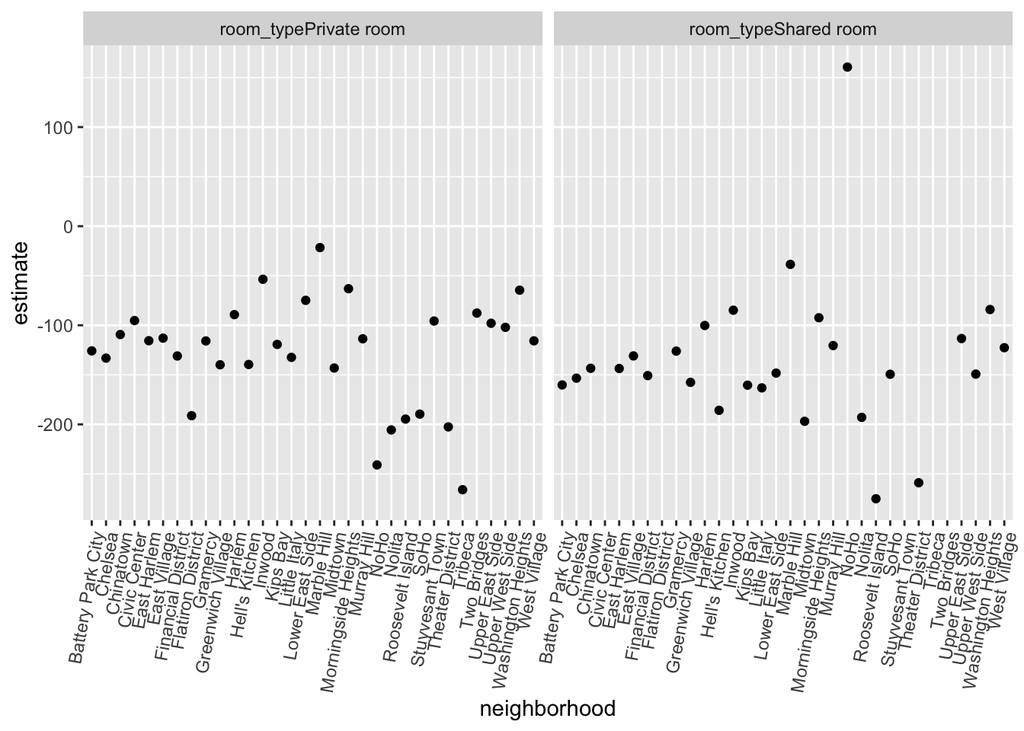

```r
manhattan_nest_lm_res %>%
  filter(str_detect(term, "room_type")) %>%
  ggplot(aes(x = neighborhood, y = estimate)) +
  geom_point() +
  facet_wrap(~term) +
  theme(axis.text.x = element_text(angle = 80, hjust = 1))
```

## Code to fix a mixed model with neighborhood-level random intercepts and slopes for room type

```r
manhattan_airbnb %>%
  lme4::lmer(price ~ stars + room_type + (1 + room_type | neighborhood), data = .) %>%
  broom.mixed::tidy()
```

```
## boundary (singular) fit: see ?isSingular
```

```
## # A tibble: 11 x 6
##    effect   group     term                          estimate std.error statistic
##    <chr>    <chr>     <chr>                            <dbl>     <dbl>     <dbl>
##  1 fixed    <NA>      (Intercept)                    250.        26.6      9.41
##  2 fixed    <NA>      stars                           -3.16       5.00    -0.631
##  3 fixed    <NA>      room_typePrivate room         -124.         7.80   -15.9
##  4 fixed    <NA>      room_typeShared room          -157.        12.9    -12.2
##  5 ran_pars neighbor… sd__(Intercept)                 59.3       NA       NA
##  6 ran_pars neighbor… cor__(Intercept).room_typePr…   -0.987     NA       NA
##  7 ran_pars neighbor… cor__(Intercept).room_typeSh…   -1.00      NA       NA
##  8 ran_pars neighbor… sd__room_typePrivate room       36.7       NA       NA
##  9 ran_pars neighbor… cor__room_typePrivate room.r…    0.992     NA       NA
## 10 ran_pars neighbor… sd__room_typeShared room        43.6       NA       NA
## 11 ran_pars Residual  sd__Observation                198.        NA       NA
```

## Binary outcomes - Logistic regression